# Reproducible Research: Peer Assessment 1

## Loading and preprocessing the data

```r
library('dplyr')
unzip('activity.zip')
activityNA <- read.csv('activity.csv')
activity <- na.omit(activityNA)
```

- The activityNA data contains all the rows and the activity data contains only the rows without NA values.

## What is mean total number of steps taken per day?

- Group the data by date and calculate the sum of steps for each day. Make the histogram for the total number of steps per day.

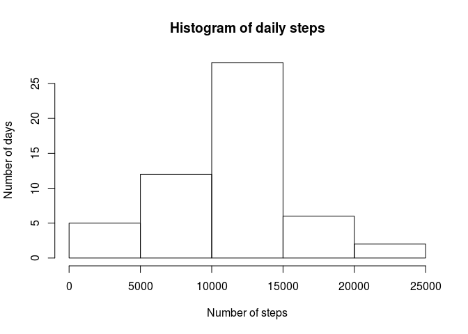

```r
by_date <- group_by(activity,date)
dailysteps <- summarize(by_date, steps = sum(steps))
par(mfcol = c(1,1))
hist(dailysteps$steps, main = 'Histogram of daily steps',
     xlab = 'Number of steps', ylab = 'Number of days')
```

- Calculate the mean and the median.

```r
mean(dailysteps$steps)
```

```
## [1] 10766.19
```

```r
median(dailysteps$steps)
```

```
## [1] 10765
```

## What is the average daily activity pattern?

- Group the data by interval and calculate the mean of steps for each interval.

```r
by_interval <- group_by(activity,interval)
meanint <- summarize(by_interval, steps = mean(steps))
```

- Add leading zeros to the interval values so that each value consists of 4 characters.

```r
for(j in 1:288) {
    if(nchar(meanint$interval[j]) == 1) {
        meanint$interval[j] <- paste('000',meanint$interval[j], sep = '')
    }
    if(nchar(meanint$interval[j]) == 2) {
        meanint$interval[j] <- paste('00',meanint$interval[j], sep = '')
    }
    if(nchar(meanint$interval[j]) == 3) {
        meanint$interval[j] <- paste('0',meanint$interval[j], sep = '')
    }
}
```

- Change the interval values to POSIXlt class values and plot the timeline.

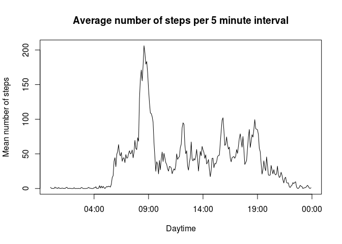

```r
tmp <- strptime(meanint$interval, '%H%M')
plot(tmp, meanint$steps, type = 'l',
     main = 'Average number of steps per 5 minute interval',
     xlab = 'Daytime', ylab = 'Mean number of steps')
```

- Identify the interval with the maximum average number of steps.

```r
tmp2 <- which(meanint$steps == max(meanint$steps))
meanint[tmp2,1]
```

```
## Source: local data frame [1 x 1]
##
##   interval
## 1     0835
```

## Imputing missing values

- The total number of missing values is 2304 which can be seen in the table.

```r
table(complete.cases(activityNA))
```

```
##
## FALSE  TRUE
##  2304 15264
```

- Idetify the rows where the missing values are located and replace the NA values with the mean number of steps for this interval.

```r
b <- which(complete.cases(activityNA) == F)

for(i in 1:2304) {
    if(b[i] %% 288 == 0) {
        activityNA$steps[b[i]] <- meanint$steps[(b[i] %% 288) + 288]
    }
    else {
        activityNA$steps[b[i]] <- meanint$steps[b[i] %% 288]
    }
}
```

- Group the new data by date, plot the new histogram and calculate mean and median.

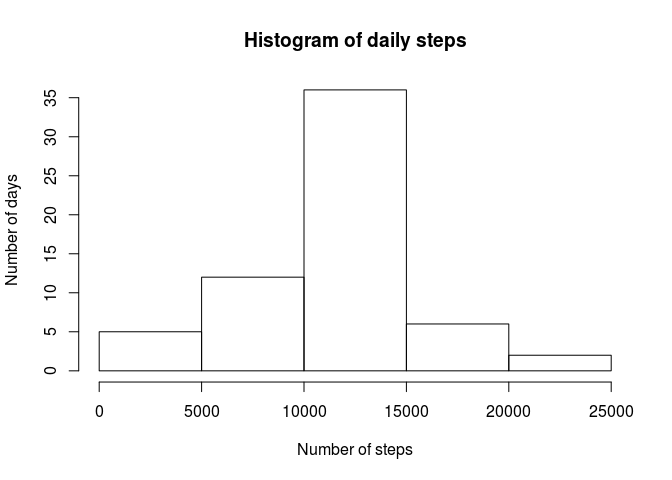

```r
by_dateNA <- group_by(activityNA,date)
dailystepsNA <- summarize(by_dateNA, steps = sum(steps))
hist(dailystepsNA$steps, main = 'Histogram of daily steps',
     xlab = 'Number of steps', ylab = 'Number of days')
```

```r
mean(dailystepsNA$steps)
```

```
## [1] 10766.19
```

```r
median(dailystepsNA$steps)
```

```
## [1] 10766.19
```

- The new mean value is still the same whereas the median value changed slightly. So the impact of imputing missing data on the estimates is not very strong.

## Are there differences in activity patterns between weekdays and weekends?

- Add leading zeros to the interval values so that each value consists of 4 characters.

```r
for(k in 1:17568) {
    if(nchar(activityNA$interval[k]) == 1) {
        activityNA$interval[k] <- paste('000', activityNA$interval[k], sep = '')
    }
    if(nchar(activityNA$interval[k]) == 2) {
        activityNA$interval[k] <- paste('00', activityNA$interval[k], sep = '')
    }
    if(nchar(activityNA$interval[k]) == 3) {
        activityNA$interval[k] <- paste('0', activityNA$interval[k], sep = '')
    }
}
```

- Building a new time variable using date and interval.

```r
activityNA <- mutate(activityNA, DateTime = paste(activityNA$date,
    activityNA$interval, sep = ' '))

activityNA$date <- NULL

activityNA$DateTime <- strptime(activityNA$DateTime, '%Y-%m-%d %H%M')
```

- Use the weekdays function to determine the weekday. The cut function makes a factor variable with two levels: weekday and weekend.

```r
wd <- weekdays(activityNA$DateTime)
test <- as.numeric(format(activityNA$DateTime,'%u'))
activityNA$wd <- cut(test, breaks = c(0,5,7), labels = c('weekday','weekend'))
activityNA$DateTime <- as.POSIXct(activityNA$DateTime)
```

- Group the data, calculate the mean number of steps for each interval for the weekday days and the weekend days.

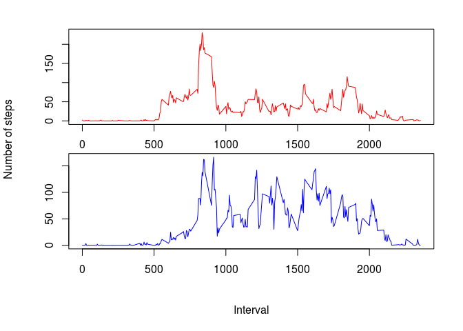

```r
by_wd <- group_by(activityNA, wd, interval)
wdmean <- summarize(by_wd, stepmean = mean(steps))
weekday <- wdmean[1:288,]
weekend <- wdmean[289:576,]

par(mfcol = c(2,1), oma = c(5,4,1,1) + 0.1,
          mar = c(1,1,1,1) + 0.1)
plot(weekday$interval,weekday$stepmean, type = 'l', col = 'red')
plot(weekend$interval,weekend$stepmean, type = 'l', col = 'blue')
title(xlab = 'Interval', ylab = 'Number of steps', outer = T)
```